# Does Weather Affect Retail? Seasonal Sales in Five Store Types

Author

Sarah Cerny

If you’ve ever worked retail you know the feeling. One week the store is dead and the next week everyone needs a winter coat Stores kind of have to guess what’s coming and every kind of store changes with the seasons in its own way. Nobody is buying a heavy puffer coat in July and nobody is buying a patio set in January. For this project I looked at five types of stores Clothing Sporting goods and hobby and book stores Building materials and garden stores General merchandise stores and food and beverage stores. I wanted to see if each one has its own seasonal pattern in real sales numbers and whether the weather has anything to do with it.

## The Dataset

I combined two sources: monthly retail sales from the Census Bureau Monthly Retail Trade survey(https://www.census.gov/retail) and monthly weather for Salt Lake City from Open-Meteo(https://open-meteo.com/en/docs/historical-weather-api). I picked Salt Lake because it actually has real seasons. Each row is one month for one store type from January 2016 to December 2025. Sales are in millions of dollars.

The cleaned dataset (data/processed/retail_weather.csv) and full data collection scripts are available in my GitHub repository for anyone who wants to reproduce these charts.

```python
import pandas as pd
import matplotlib.pyplot as plt
import seaborn as sns

sns.set_theme(style="whitegrid", context="notebook")

month_names = ["Jan", "Feb", "Mar", "Apr", "May", "Jun",
               "Jul", "Aug", "Sep", "Oct", "Nov", "Dec"]

retail = pd.read_csv("data/processed/retail_weather.csv")

retail["seasonal_index"] = retail["sales_millions"] / retail.groupby(
    ["category", "year"])["sales_millions"].transform("mean")

no_2020 = retail.loc[retail["year"] != 2020].copy()

print("Rows:", len(retail))
print("Columns:", retail.shape[1])
print("Store categories:", retail["category"].nunique())
```

```
Rows: 600
Columns: 8
Store categories: 5
```

**What we see:** The dataset has 600 total rows covering 5 store types across 120 months each so there are no missing months. The store types are all completely different sizes. Food and beverage is by far the biggest averaging around $71.1 billion a month with general merchandise right behind it at about $67.6 billion. Building materials sits in the middle around $36.8 billion and clothing comes in around $21.9 billion. Sporting goods is the smallest at roughly $7.2 billion a month. That is exactly why I went with the seasonal index because graphing raw dollar amounts would make the smaller stores look totally flat.

### Salt Lake City’s climate

[figure not shown]

```python
weather = retail.drop_duplicates(["year", "month"])

fig, axes = plt.subplots(2, 1, figsize=(8, 8))

sns.lineplot(
    data=weather,
    x="month",
    y="avg_temp_f",
    marker="o",
    color="firebrick",
    ax=axes[0],
)

axes[0].set_xticks(range(1, 13), labels=[])

axes[0].set(
    xlabel="",
    ylabel="Average temperature (°F)",
    title="Temperature by month",
)


sns.barplot(
    data=weather,
    x="month",
    y="total_precip_in",
    color="lightsteelblue",
    errorbar=None,
    ax=axes[1],
)
axes[1].set_xticks(range(1, 13), labels=month_names)
axes[1].set(
    xlabel="",
    ylabel="Total precipitation (inches)",
    title="Precipitation by month",
)

fig.suptitle("Salt Lake City climate, 2016-2025")
fig.tight_layout()
plt.show()
```

**What we see:** Salt Lake has really clear seasons. It’s hottest in July about 82F on average and coldest in January about 30F It’s wettest in March about 3.4 inches with April next and then it dries out a ton over the summer july only gets about 0.16 inches the light band around the temperature line shows how much each month changes from year to year.

## Monthly Seasonality

**Question:** Do different kinds of stores peak in different months?

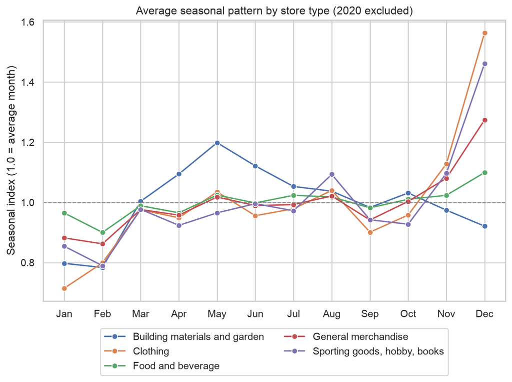

```python
 # Monthly Seasonality Plot
season = no_2020.groupby(["category", "month"])["seasonal_index"].mean().reset_index()

fig, ax = plt.subplots(figsize=(9, 5.5))
sns.lineplot(
    data=season,
    x="month",
    y="seasonal_index",
    hue="category",
    marker="o",
    ax=ax
)
ax.axhline(1.0, color="gray", linestyle="--", linewidth=1)
ax.set_xticks(range(1, 13), labels=month_names)
ax.set(
    xlabel="",
    ylabel="Seasonal index (1.0 = average month)",
    title="Average seasonal pattern by store type (2020 excluded)"
)
ax.legend(title=None, loc="upper center", bbox_to_anchor=(0.5, -0.08), ncol=2)
plt.show()
```

**What we see:** Every store type has its own rhythm clothing swings the most. Its best month is December index of 1.56 and its worst is January so the average December is about 2.2 times bigger than the average January sporting goods is next at about 1. 85 times Building materials peaks in May and bottoms out in February which is the spring peak I guessed. In 2016 alone it went from about $21.3 billion in January to about $33.4 billion in May. Food and beverage is the flattest at about 1.22 times which makes sense since people buy groceries no matter what season it is It still gets about a 10% bump in December though The holiday season shows up for the other store types too mostly in December. Clothing sporting goods and general merchandise all peak then and November is a smaller bump of about 8% to 13%.

## What Did 2020 Do?

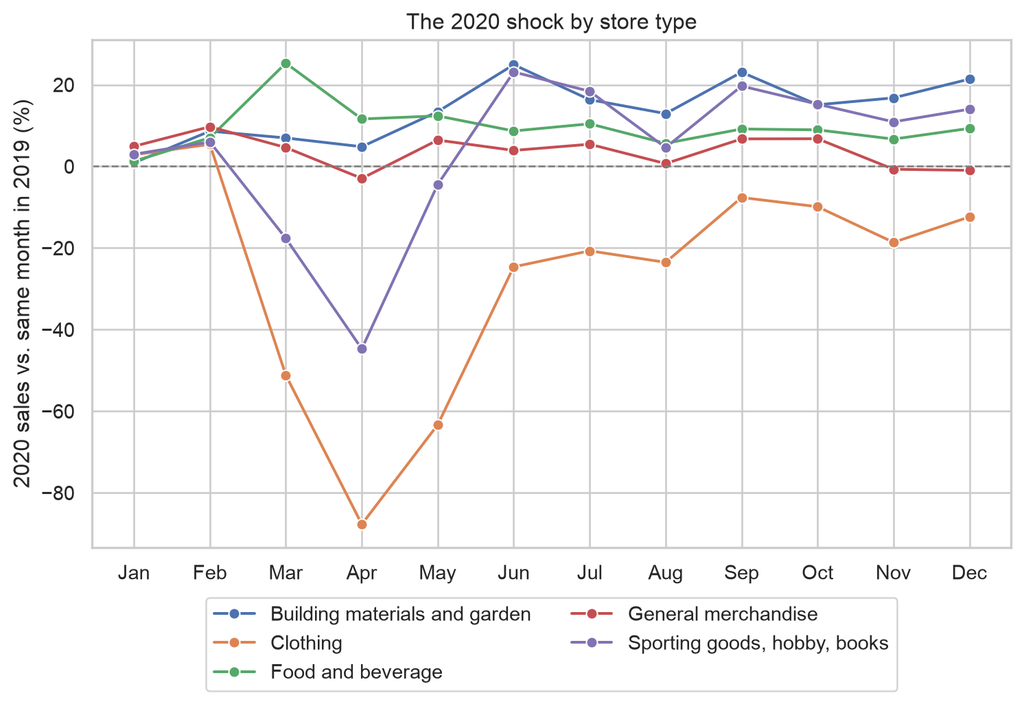

```python
sales_by_year = retail.pivot_table(index=["category", "month"], columns="year",
                                   values="sales_millions")
change_2020 = ((sales_by_year[2020] / sales_by_year[2019] - 1) * 100).rename("pct_change").reset_index()

fig, ax = plt.subplots(figsize=(9, 5))
sns.lineplot(data=change_2020, x="month", y="pct_change", hue="category",
             marker="o", ax=ax)
ax.axhline(0, color="gray", linestyle="--", linewidth=1)
ax.set_xticks(range(1, 13), labels=month_names)
ax.set(xlabel="", ylabel="2020 sales vs. same month in 2019 (%)",
       title="The 2020 shock by store type")
ax.legend(title=None, loc="upper center", bbox_to_anchor=(0.5, -0.08), ncol=2)
plt.show()
```

**What we see:** 2020 really messed up normal patterns but clothing got hit the hardest dropping 88% in April down to just $2.5 billion sporting goods was the next worst dropping 45% in April before bouncing back fast by June. On the flip side food and beverage and building materials never dropped below 2019 levels as people stocked up on groceries and started DIY projects at home general merchandise stayed surprisingly steady while clothing remained the slowest to recover through the end of the year.

Because 2020 had such extreme pandemic drops and spikes—like clothing falling 88% in April—including it would have artificially pulled down the spring averages and distorted what a ‘normal’ year looks like.